# 2016 Seimo rinkimo antro turo analizė II

Šitam dokumente pabandysim pateikti “dvaro politologo” Mažvydo Jastramskio prognozę antram turui.

Mažvydas Jastramskis sako, kad antrą turą paprastai laimi laimėtojai. Nebent skirtumas yra mažas ir antros vietos laimėtojo partijai nemažai surinko balsų daugiamandatėje apygardoje.

Taigi visų pirma identifikuokim kas yra mažas skirtumas tarp kandidatų. Mažvydas siūlo imti pirmą kvartilį. Visų pirma pasižiūrėkim kaip apskritai atrodo skirtumai:

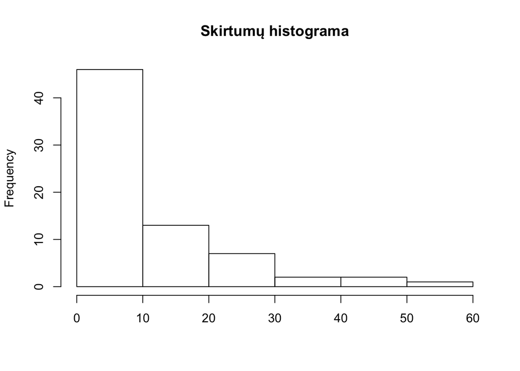

Matome, kad virš 40% apygardų skirtumas yra mažesnis nei 10%. Skirtmų kvartiliai atrodo taip

```
0%    25%    50%    75%   100%
```

0.040 2.045 7.600 14.705 57.760

Taigi imsime tas apygardas tarp kurių skirtumas yra mažesnis už 2%.

| apygarda | kandidatas | partija | proc_rinkejai |
| --- | --- | --- | --- |
| Naujosios Vilnios | ALGIRDAS PALECKIS | SI | 23.08 |
| Naujosios Vilnios | MONIKA NAVICKIENĖ | TSLKD | 22.99 |
| Dainavos | JUOZAS PUNDZIUS | TSLKD | 23.84 |
| Dainavos | LAURAS STACEVIČIUS | LVZS | 22.86 |
| Aleksoto-Vilijampolės | MINDAUGAS PUIDOKAS | LVZS | 26.32 |
| Aleksoto-Vilijampolės | EDITA GUDIŠAUSKIENĖ | TSLKD | 24.43 |
| Marių | DAINIUS KEPENIS | LVZS | 18.10 |
| Marių | EDMUNDAS KVEDERIS | LRLS | 16.51 |
| Pajūrio | GINTARAS VAIČEKAUSKAS | LRLS | 17.83 |
| Pajūrio | ARŪNAS BARBŠYS | TSLKD | 17.31 |
| Danės | NAGLIS PUTEIKIS | PUTKA | 24.26 |
| Danės | SIMONAS GENTVILAS | LRLS | 23.10 |
| Plungės | JONAS VARKALYS | LRLS | 24.29 |
| Plungės | JURGIS RAZMA | TSLKD | 24.24 |
| Mažeikių | KĘSTUTIS BARTKEVIČIUS | PTT | 25.51 |
| Mažeikių | LINA RIMKIENĖ | TSLKD | 25.47 |
| Radviliškio | AURIMAS GAIDŽIŪNAS | LVZS | 18.06 |
| Radviliškio | VYTAUTAS JUOZAPAITIS | TSLKD | 16.96 |
| Biržų-Kupiškio | ALEKSANDRAS ZELTINIS | LSDP | 19.27 |
| Biržų-Kupiškio | AUDRYS ŠIMAS | LVZS | 18.01 |
| Anykščių-Panevėžio | GRETA KILDIŠIENĖ | LVZS | 24.29 |
| Anykščių-Panevėžio | SERGEJUS JOVAIŠA | TSLKD | 23.62 |
| Sėlos | VYTAUTAS SAULIS | LSDP | 20.44 |
| Sėlos | RAIMUNDAS MARTINĖLIS | SI | 18.89 |
| Molėtų-Širvintų | PETRAS ČIMBARAS | DP | 25.32 |
| Molėtų-Širvintų | VALENTINAS STUNDYS | TSLKD | 23.40 |
| Trakų-Vievio | JONAS LIESYS | LRLS | 14.64 |
| Trakų-Vievio | DANGUTĖ MIKUTIENĖ | DP | 14.28 |
| Ukmergės | AGNĖ BALČIŪNIENĖ | TSLKD | 19.58 |
| Ukmergės | JUOZAS VARŽGALYS | LVZS | 18.25 |
| Jurbarko-Pagėgių | DAIVARAS RYBAKOVAS | TSLKD | 17.36 |
| Jurbarko-Pagėgių | RIČARDAS JUŠKA | LRLS | 16.87 |
| Zanavykų | MINDAUGAS BASTYS | LSDP | 18.78 |
| Zanavykų | ARVYDAS VIDŽIŪNAS | TSLKD | 18.71 |
| Lazdijų-Druskininkų | ZENONAS STREIKUS | LVZS | 21.04 |
| Lazdijų-Druskininkų | KRISTINA MIŠKINIENĖ | LSDP | 20.35 |

Kaip matome skirtumai tikrai nėra dideli. Prijungiam duomenis iš daugiamandačių imdami tik tas partijas, kurių kandidatai praėjo į antrą turą.

| apygardos_no | apygarda | partija | proc_rinkejai | kandidato_proc | kandidatas |
| --- | --- | --- | --- | --- | --- |
| 10 | Naujosios Vilnios | TSLKD | 21.49 | 22.99 | MONIKA NAVICKIENĖ |
| 16 | Dainavos | TSLKD | 26.08 | 23.84 | JUOZAS PUNDZIUS |
| 16 | Dainavos | LVZS | 24.30 | 22.86 | LAURAS STACEVIČIUS |
| 19 | Aleksoto-Vilijampolės | TSLKD | 28.22 | 24.43 | EDITA GUDIŠAUSKIENĖ |
| 19 | Aleksoto-Vilijampolės | LVZS | 25.67 | 26.32 | MINDAUGAS PUIDOKAS |
| 21 | Marių | LVZS | 16.91 | 18.10 | DAINIUS KEPENIS |
| 21 | Marių | LRLS | 13.09 | 16.51 | EDMUNDAS KVEDERIS |
| 22 | Pajūrio | TSLKD | 20.27 | 17.31 | ARŪNAS BARBŠYS |
| 22 | Pajūrio | LRLS | 15.36 | 17.83 | GINTARAS VAIČEKAUSKAS |
| 23 | Danės | LRLS | 16.39 | 23.10 | SIMONAS GENTVILAS |
| 23 | Danės | PUTKA | 11.89 | 24.26 | NAGLIS PUTEIKIS |
| 35 | Plungės | TSLKD | 19.48 | 24.24 | JURGIS RAZMA |
| 35 | Plungės | LRLS | 10.78 | 24.29 | JONAS VARKALYS |
| 38 | Mažeikių | TSLKD | 17.79 | 25.47 | LINA RIMKIENĖ |
| 38 | Mažeikių | PTT | 9.45 | 25.51 | KĘSTUTIS BARTKEVIČIUS |
| 44 | Radviliškio | TSLKD | 17.80 | 16.96 | VYTAUTAS JUOZAPAITIS |
| 44 | Radviliškio | LVZS | 29.34 | 18.06 | AURIMAS GAIDŽIŪNAS |
| 48 | Biržų-Kupiškio | LVZS | 27.27 | 18.01 | AUDRYS ŠIMAS |
| 48 | Biržų-Kupiškio | LSDP | 18.06 | 19.27 | ALEKSANDRAS ZELTINIS |
| 49 | Anykščių-Panevėžio | TSLKD | 20.82 | 23.62 | SERGEJUS JOVAIŠA |
| 49 | Anykščių-Panevėžio | LVZS | 30.25 | 24.29 | GRETA KILDIŠIENĖ |
| 50 | Sėlos | LSDP | 18.84 | 20.44 | VYTAUTAS SAULIS |
| 54 | Molėtų-Širvintų | TSLKD | 19.29 | 23.40 | VALENTINAS STUNDYS |
| 54 | Molėtų-Širvintų | DP | 21.01 | 25.32 | PETRAS ČIMBARAS |
| 58 | Trakų-Vievio | LRLS | 12.16 | 14.64 | JONAS LIESYS |
| 58 | Trakų-Vievio | DP | 7.29 | 14.28 | DANGUTĖ MIKUTIENĖ |
| 61 | Ukmergės | TSLKD | 18.52 | 19.58 | AGNĖ BALČIŪNIENĖ |
| 61 | Ukmergės | LVZS | 24.81 | 18.25 | JUOZAS VARŽGALYS |
| 62 | Jurbarko-Pagėgių | TSLKD | 18.19 | 17.36 | DAIVARAS RYBAKOVAS |
| 62 | Jurbarko-Pagėgių | LRLS | 8.38 | 16.87 | RIČARDAS JUŠKA |
| 64 | Zanavykų | TSLKD | 20.90 | 18.71 | ARVYDAS VIDŽIŪNAS |
| 64 | Zanavykų | LSDP | 18.54 | 18.78 | MINDAUGAS BASTYS |
| 71 | Lazdijų-Druskininkų | LVZS | 23.73 | 21.04 | ZENONAS STREIKUS |
| 71 | Lazdijų-Druskininkų | LSDP | 20.43 | 20.35 | KRISTINA MIŠKINIENĖ |

Matome, kad yra apygardų, kuriose praėjo save iškėlęs kandidatas, taigi turime jas išmesti iš analizės.

| apygardos_no | apygarda | n |
| --- | --- | --- |
| 10 | Naujosios Vilnios | 1 |
| 50 | Sėlos | 1 |

Suskaičiuojame skirtumus.

| apygardos_no | apygarda | duetas | dm_skirtumas | vm_skirtumas |
| --- | --- | --- | --- | --- |
| 16 | Dainavos | TSLKD-LVZS | 1.78 | 0.98 |
| 19 | Aleksoto-Vilijampolės | LVZS-TSLKD | -2.55 | 1.89 |
| 21 | Marių | LVZS-LRLS | 3.82 | 1.59 |
| 22 | Pajūrio | LRLS-TSLKD | -4.91 | 0.52 |
| 23 | Danės | PUTKA-LRLS | -4.50 | 1.16 |
| 35 | Plungės | LRLS-TSLKD | -8.70 | 0.05 |
| 38 | Mažeikių | PTT-TSLKD | -8.34 | 0.04 |
| 44 | Radviliškio | LVZS-TSLKD | 11.54 | 1.10 |
| 48 | Biržų-Kupiškio | LSDP-LVZS | -9.21 | 1.26 |
| 49 | Anykščių-Panevėžio | LVZS-TSLKD | 9.43 | 0.67 |
| 54 | Molėtų-Širvintų | DP-TSLKD | 1.72 | 1.92 |
| 58 | Trakų-Vievio | LRLS-DP | 4.87 | 0.36 |
| 61 | Ukmergės | TSLKD-LVZS | -6.29 | 1.33 |
| 62 | Jurbarko-Pagėgių | TSLKD-LRLS | 9.81 | 0.49 |
| 64 | Zanavykų | LSDP-TSLKD | -2.36 | 0.07 |
| 71 | Lazdijų-Druskininkų | LVZS-LSDP | 3.30 | 0.69 |

Matome atsiranda įdomybių. Pvz Radviliškyje konservatorių kandidatas vienmandatėje pralaimėjo tik 1%, bet daugiamandatėje konservatoriai valstiečiams nusileido net 11%. Biržuose socialdemokratų kandidatas buvo pirmas vienmandatėje, bet socialdemokratai net 9 procentais nusileido jo konkurento partijai daugiamandatėje.

Priskiriam pergalę tam kandidatui, kurio vienmandatėje buvo antras, bet jo partija surinko daugiau balsų daugiamandatėje, priešingu atveju paliekam pergalę vienmandatę laimėjusiam kandidatui

| apygardos_no | apygarda | pirmas | antras | dm_skirtumas | vm_skirtumas | laimejo |
| --- | --- | --- | --- | --- | --- | --- |
| 16 | Dainavos | TSLKD | LVZS | 1.78 | 0.98 | TSLKD |
| 19 | Aleksoto-Vilijampolės | LVZS | TSLKD | -2.55 | 1.89 | TSLKD |
| 21 | Marių | LVZS | LRLS | 3.82 | 1.59 | LVZS |
| 22 | Pajūrio | LRLS | TSLKD | -4.91 | 0.52 | TSLKD |
| 23 | Danės | PUTKA | LRLS | -4.50 | 1.16 | LRLS |
| 35 | Plungės | LRLS | TSLKD | -8.70 | 0.05 | TSLKD |
| 38 | Mažeikių | PTT | TSLKD | -8.34 | 0.04 | TSLKD |
| 44 | Radviliškio | LVZS | TSLKD | 11.54 | 1.10 | LVZS |
| 48 | Biržų-Kupiškio | LSDP | LVZS | -9.21 | 1.26 | LVZS |
| 49 | Anykščių-Panevėžio | LVZS | TSLKD | 9.43 | 0.67 | LVZS |
| 54 | Molėtų-Širvintų | DP | TSLKD | 1.72 | 1.92 | DP |
| 58 | Trakų-Vievio | LRLS | DP | 4.87 | 0.36 | LRLS |
| 61 | Ukmergės | TSLKD | LVZS | -6.29 | 1.33 | LVZS |
| 62 | Jurbarko-Pagėgių | TSLKD | LRLS | 9.81 | 0.49 | TSLKD |
| 64 | Zanavykų | LSDP | TSLKD | -2.36 | 0.07 | TSLKD |
| 71 | Lazdijų-Druskininkų | LVZS | LSDP | 3.30 | 0.69 | LVZS |

Dabar belieka sujungti šituos duomenis su likusiom kitom apygardom, ir suvesti rezultatus

| laimejo | mandatai |
| --- | --- |
| TSLKD | 26 |
| LVZS | 22 |
| LSDP | 8 |
| DP | 3 |
| LLRA | 3 |
| LRLS | 3 |
| PTT | 3 |
| SI | 2 |
| LS | 1 |

Palyginam su pirmąja prognoze, kurioje vienmandatę antrame ture laimi tas, kuris laimėjo pirmame:

| laimejo | lyderis | pretendentas |
| --- | --- | --- |
| TSLKD | 22 | 26 |
| LVZS | 21 | 22 |
| LSDP | 10 | 8 |
| LRLS | 4 | 3 |
| PTT | 4 | 3 |
| DP | 3 | 3 |
| LLRA | 3 | 3 |
| SI | 2 | 2 |
| LS | 1 | 1 |
| PUTKA | 1 | 0 |

Pridedam daugiamandačių rezultatus ir turime tokį galimą vaizdą Seime:

| partija | lyderis | pretendentas |
| --- | --- | --- |
| TSLKD | 42 | 46 |
| LVZS | 40 | 41 |
| LSDP | 23 | 21 |
| LRLS | 12 | 11 |
| PTT | 9 | 8 |
| DP | 3 | 3 |
| LLRA | 8 | 8 |
| SI | 2 | 2 |
| LS | 1 | 1 |
| PUTKA | 1 | 0 |

Matome kad pirmuoju atveju valstiečiai su socdemais ir lenkais turi minimalią daugumą Seime. Ouch. Abiem atvejais konservatoriams be valstiečių niekaip neišeina surinkti daugumos į koaliciją nepaimant tvarkiečių arba socdemų. Ramzio žudikai gali netyčia tapti kingmakeriais. Bet kuriuo atveju konservatoriai kartu su valstiečiais gali paimti Seimą be jokios pagalbos ir be normalios opozicijos. Bus įdomu.